# examples_0317

A turtle starts at the central red dot facing North. It uses the following commands:

- Character `F` means drag pen **Forward**
- Character `+` means turn 90° right (clockwise)
- Character `-` means turn 90° left (counterclockwise)
- Character `X` means hop forward without drawing
- Character `[` means save current position at top of pile
- Character `]` means teleport to saved position (use position at top of pile and remove that position from pile)

Use the following command string:

`F[-FFFF]FFFFFF[-FF]FF+FFFFFFFFF`

Which drawing is correct?

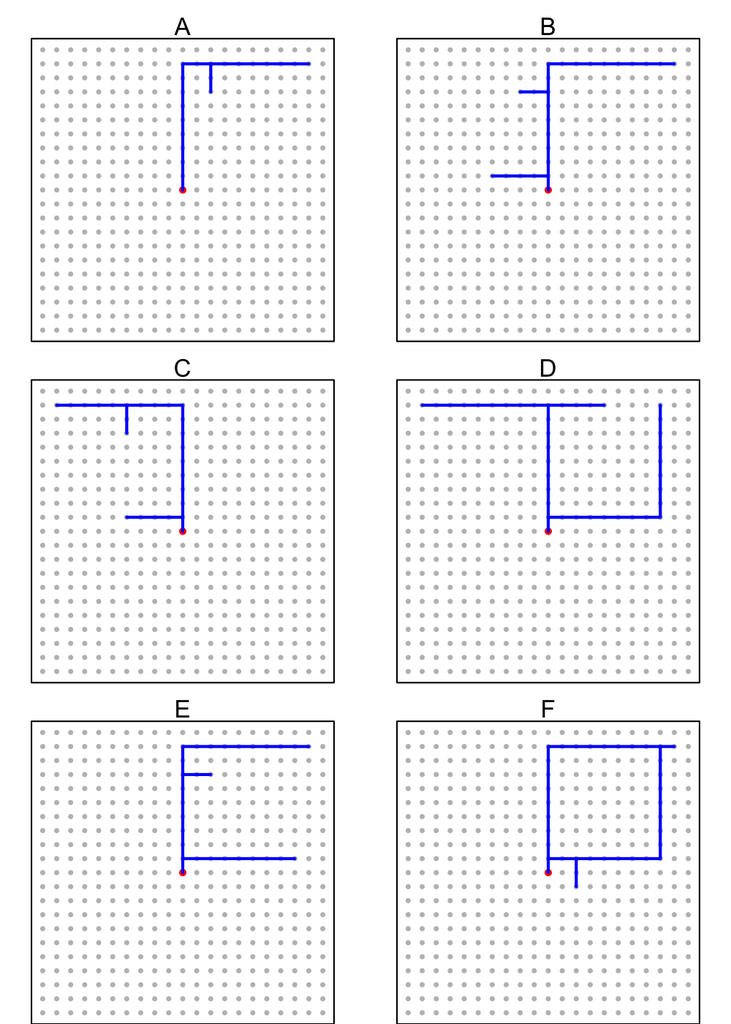

ABCDEF

The correct answer is B.

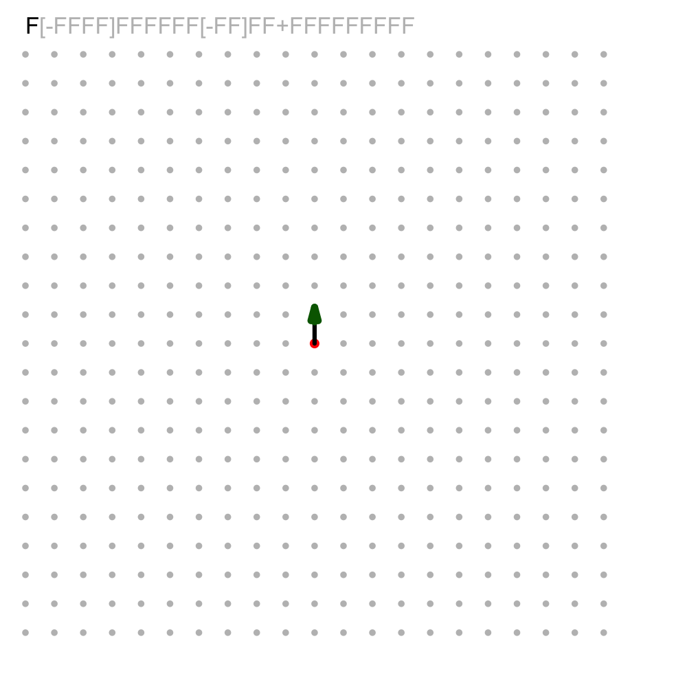

A turtle starts at the central red dot facing North. It uses the following commands:

- Character `F` means drag pen **Forward**
- Character `+` means turn 90° right (clockwise)
- Character `-` means turn 90° left (counterclockwise)
- Character `X` means hop forward without drawing
- Character `[` means save current position at top of pile
- Character `]` means teleport to saved position (use position at top of pile and remove that position from pile)

Use the following command string:

`F+FFFF-FFFF[-FFFFFFFF]FFFF+FFFFF`

Which drawing is correct?

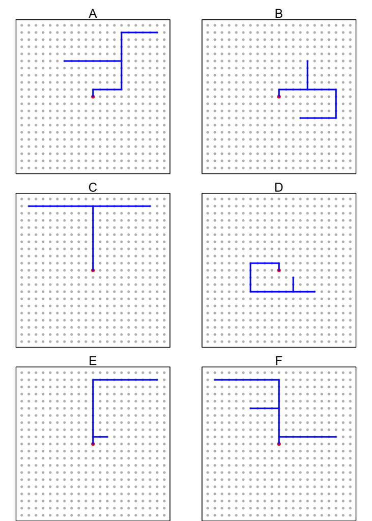

ABCDEF

The correct answer is A.

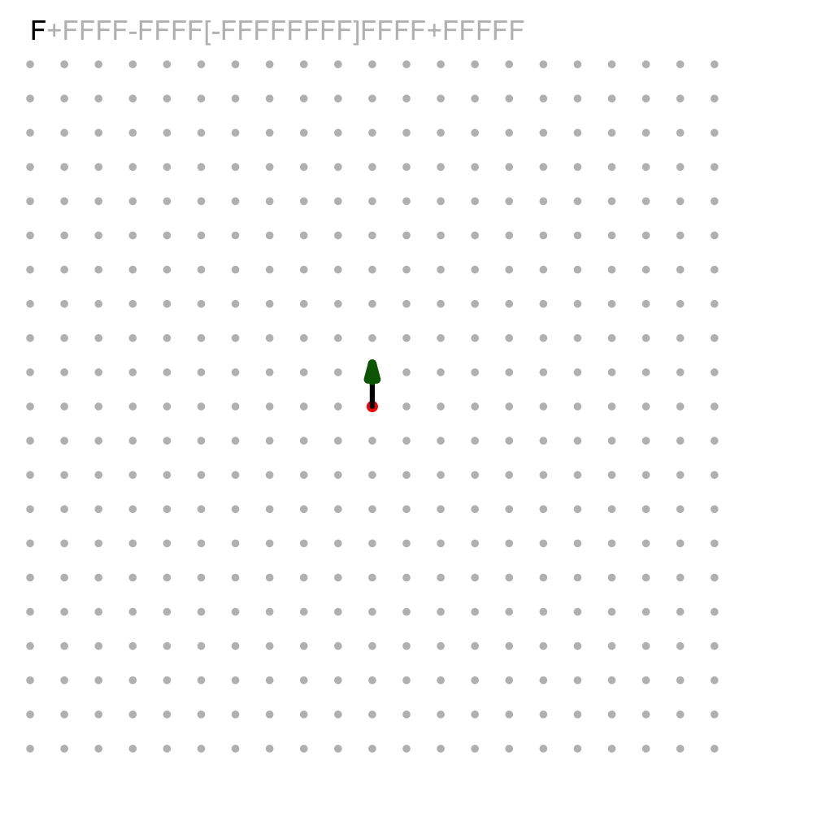

A turtle starts at the central red dot facing North. It uses the following commands:

- Character `F` means drag pen **Forward**
- Character `+` means turn 90° right (clockwise)
- Character `-` means turn 90° left (counterclockwise)
- Character `X` means hop forward without drawing
- Character `[` means save current position at top of pile
- Character `]` means teleport to saved position (use position at top of pile and remove that position from pile)

Use the following command string:

`F-FFFF[+FFFF]FF-FF-FFFFFFFFF`

Which drawing is correct?

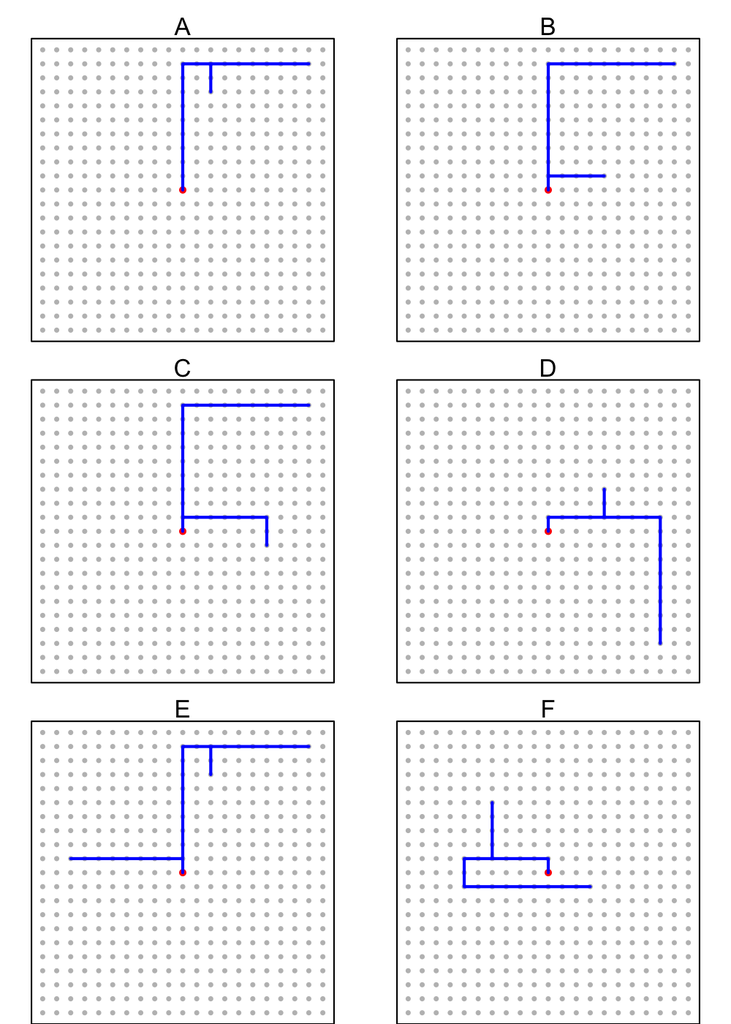

ABCDEF

The correct answer is F.

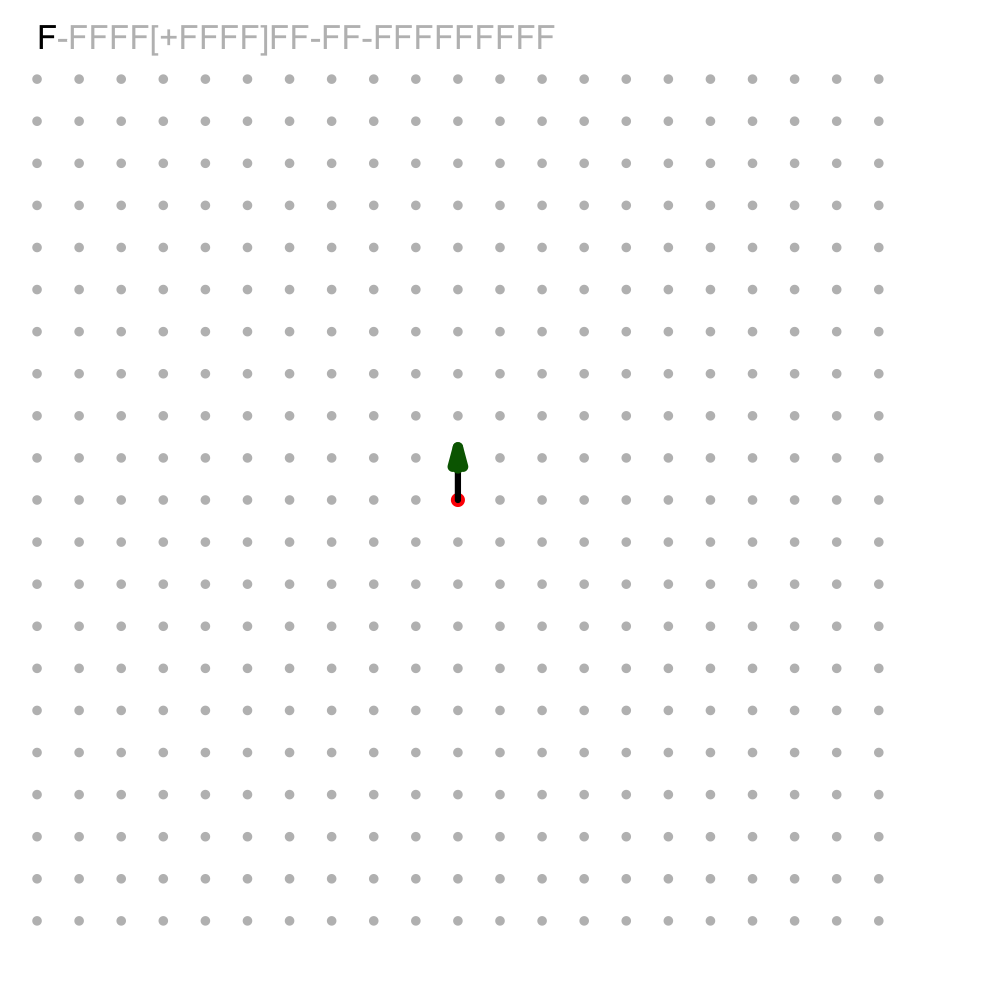

A turtle starts at the central red dot facing North. It uses the following commands:

- Character `F` means drag pen **Forward**
- Character `+` means turn 90° right (clockwise)
- Character `-` means turn 90° left (counterclockwise)
- Character `X` means hop forward without drawing
- Character `[` means save current position at top of pile
- Character `]` means teleport to saved position (use position at top of pile and remove that position from pile)

Use the following command string:

`F+FFFF[+FF]FFFF-FFFF-FFFFF`

Which drawing is correct?

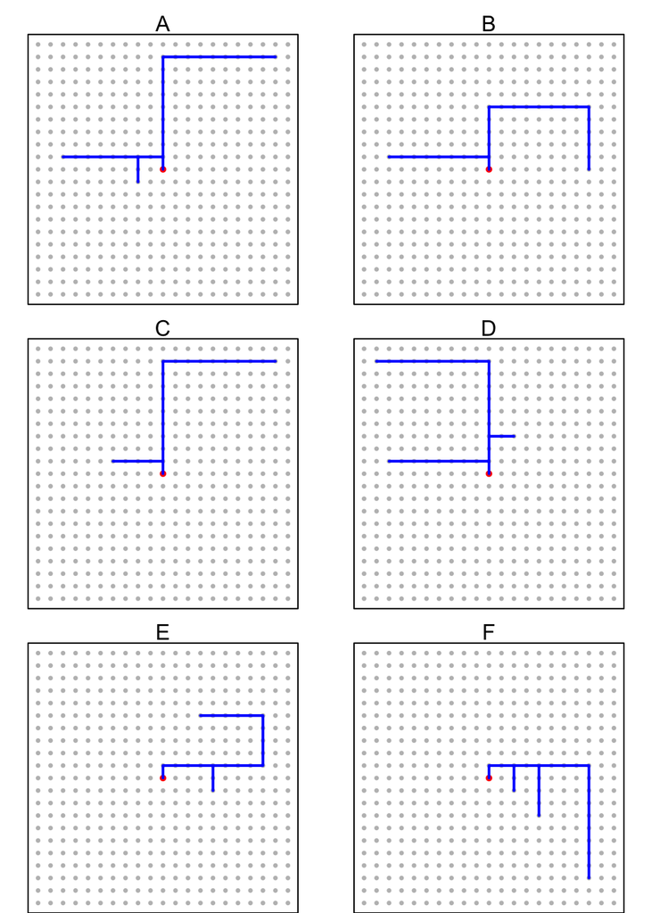

ABCDEF

The correct answer is E.

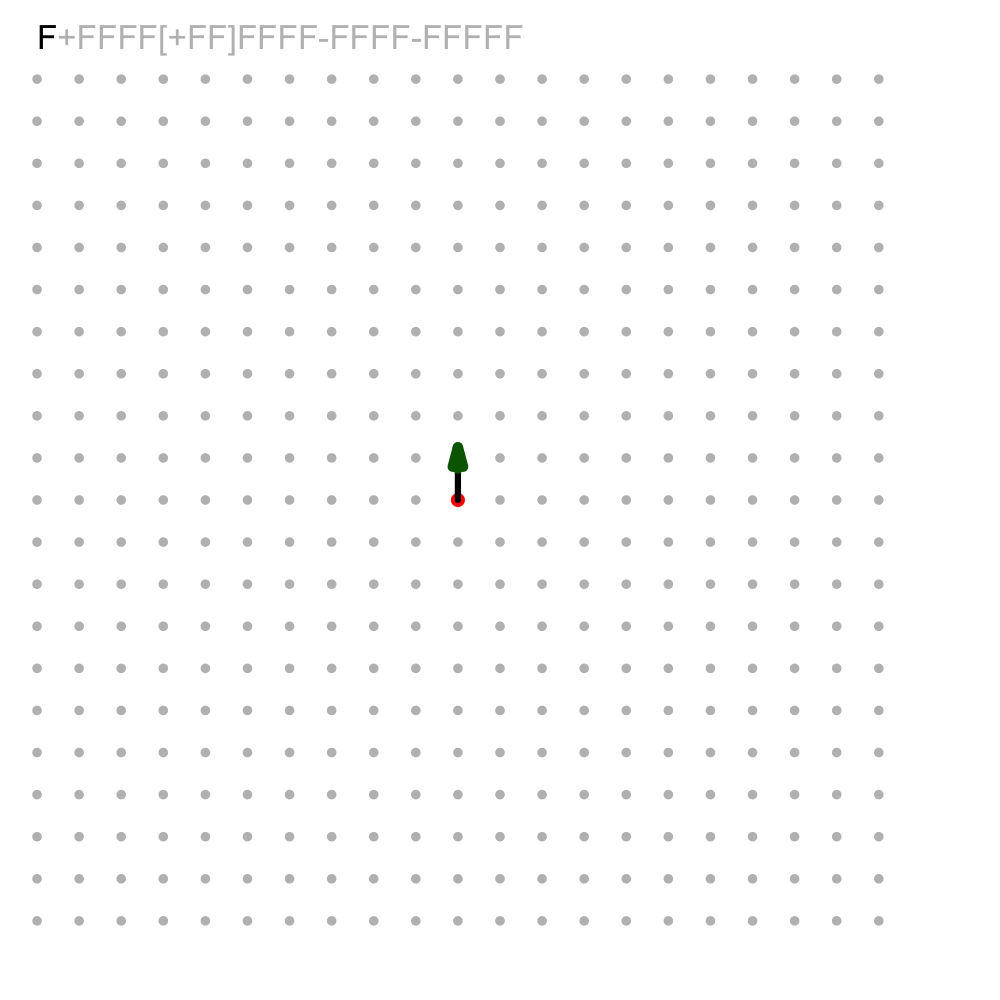

A turtle starts at the central red dot facing North. It uses the following commands:

- Character `F` means drag pen **Forward**
- Character `+` means turn 90° right (clockwise)
- Character `-` means turn 90° left (counterclockwise)
- Character `X` means hop forward without drawing
- Character `[` means save current position at top of pile
- Character `]` means teleport to saved position (use position at top of pile and remove that position from pile)

Use the following command string:

`F-FFFFFFFF-FFFF[-FFFF]FF[-FF]FFF`

Which drawing is correct?

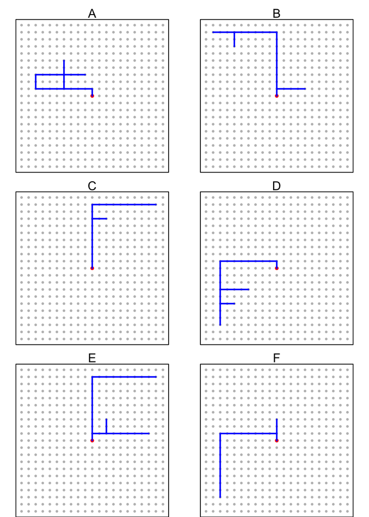

ABCDEF

The correct answer is D.

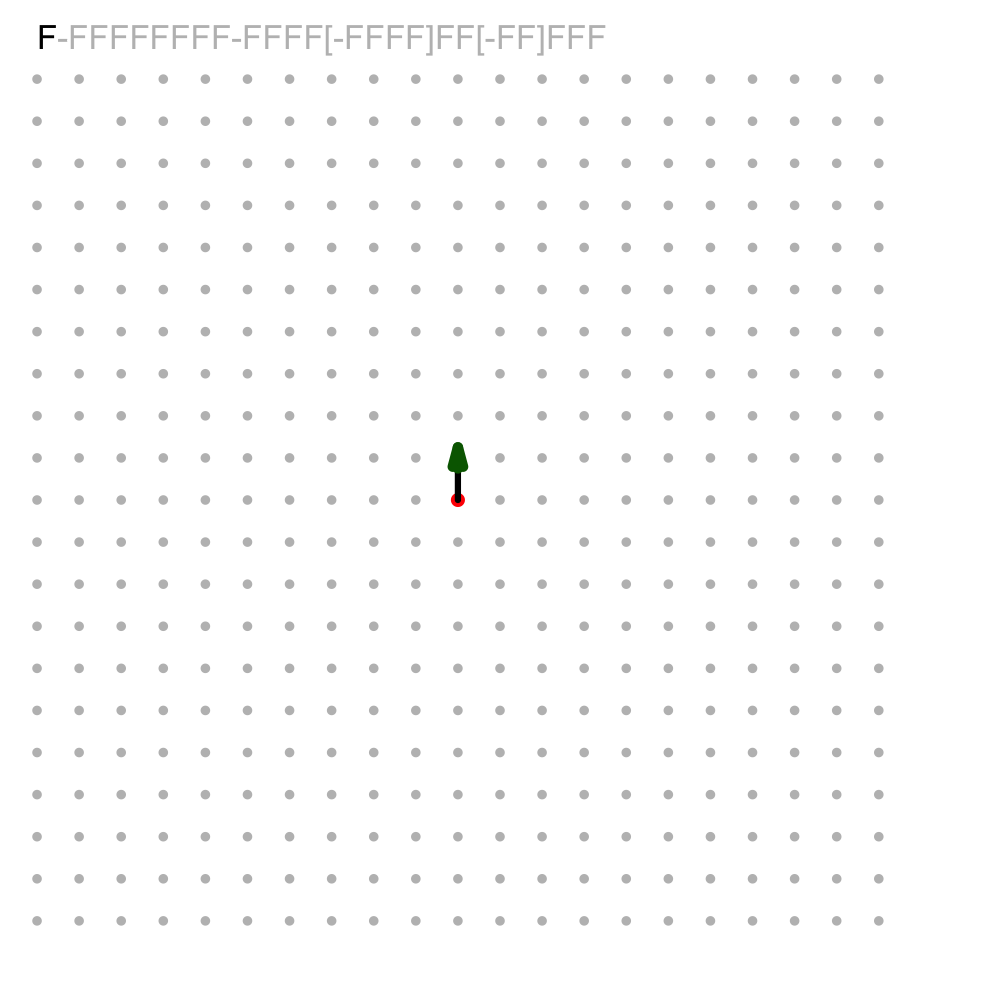

A turtle starts at the central red dot facing North. It uses the following commands:

- Character `F` means drag pen **Forward**
- Character `+` means turn 90° right (clockwise)
- Character `-` means turn 90° left (counterclockwise)
- Character `X` means hop forward without drawing
- Character `[` means save current position at top of pile
- Character `]` means teleport to saved position (use position at top of pile and remove that position from pile)

Use the following command string:

`FFFFFFF[-FF]FF+FFFFFFFFF`

Which drawing is correct?

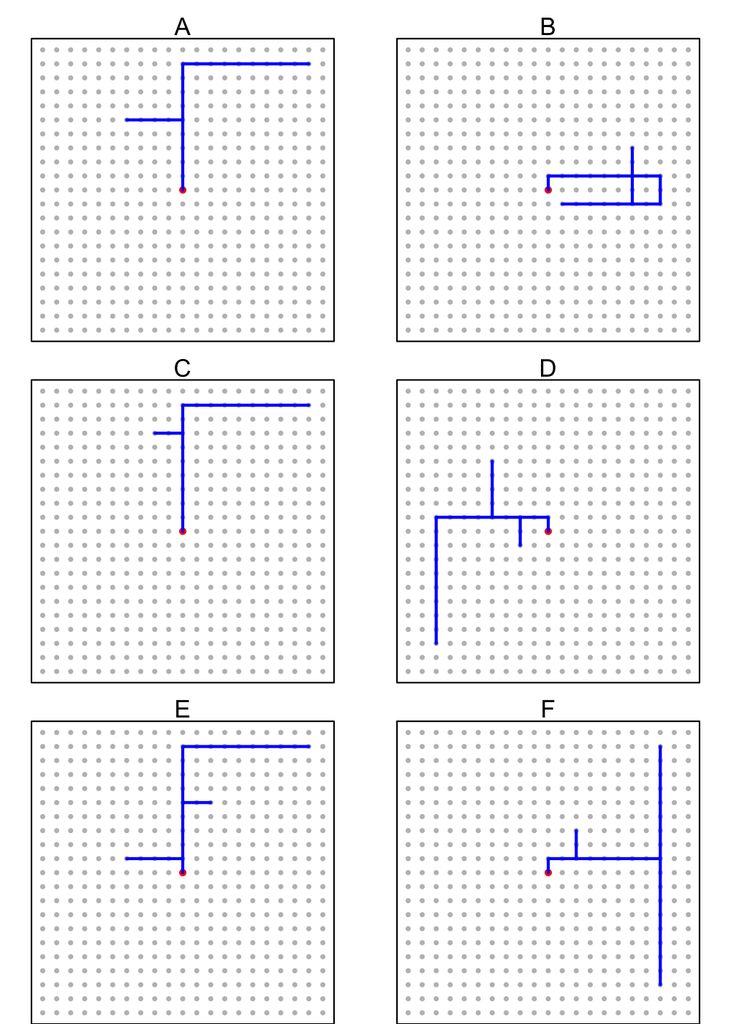

ABCDEF

The correct answer is C.

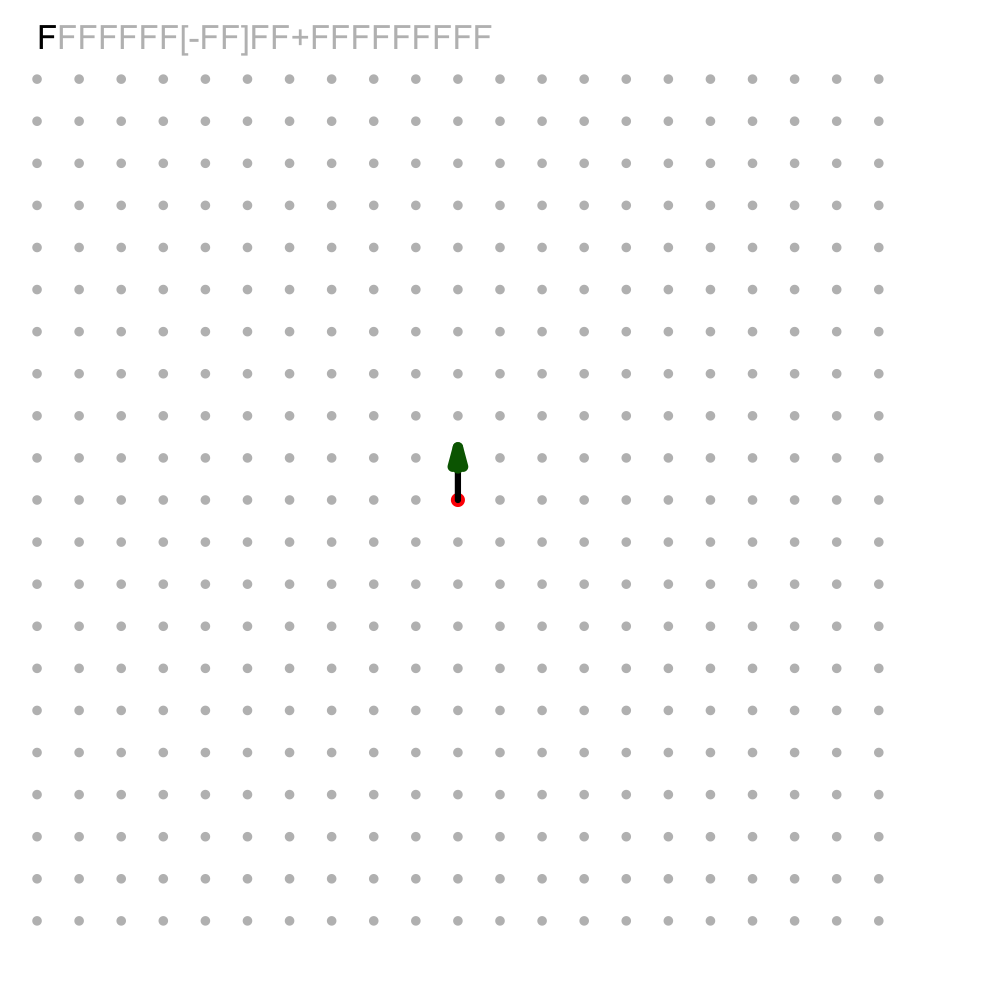

A turtle starts at the central red dot facing North. It uses the following commands:

- Character `F` means drag pen **Forward**
- Character `+` means turn 90° right (clockwise)
- Character `-` means turn 90° left (counterclockwise)
- Character `X` means hop forward without drawing
- Character `[` means save current position at top of pile
- Character `]` means teleport to saved position (use position at top of pile and remove that position from pile)

Use the following command string:

`F[-FFFF]FFFFFFFF-FFFF[-FF]FFFFF`

Which drawing is correct?

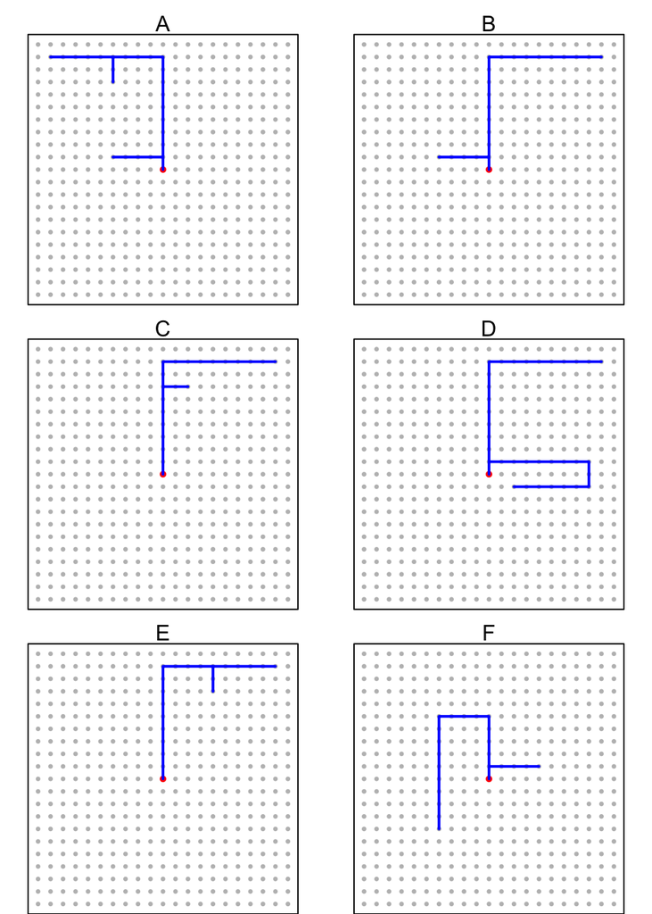

ABCDEF

The correct answer is A.

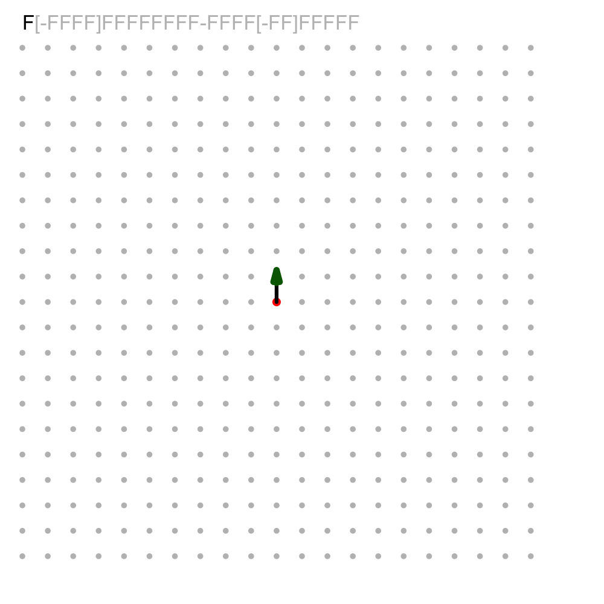

A turtle starts at the central red dot facing North. It uses the following commands:

- Character `F` means drag pen **Forward**
- Character `+` means turn 90° right (clockwise)
- Character `-` means turn 90° left (counterclockwise)
- Character `X` means hop forward without drawing
- Character `[` means save current position at top of pile
- Character `]` means teleport to saved position (use position at top of pile and remove that position from pile)

Use the following command string:

`F[-FF-FF]FFFFFFFF-FFFFFFFFF`

Which drawing is correct?

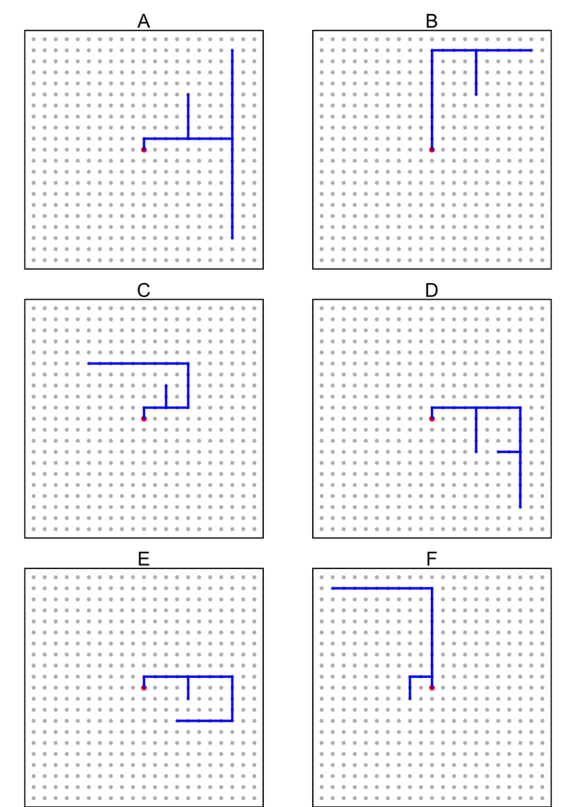

ABCDEF

The correct answer is F.

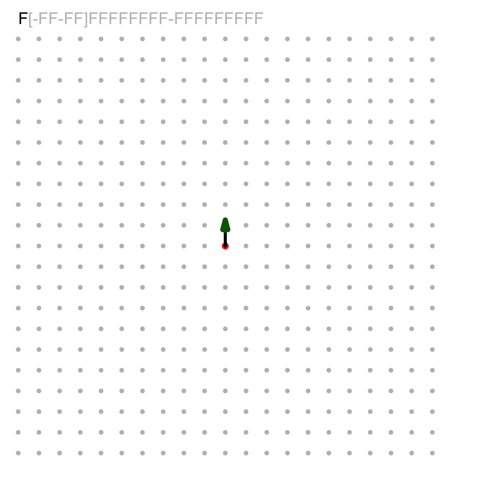

A turtle starts at the central red dot facing North. It uses the following commands:

- Character `F` means drag pen **Forward**
- Character `+` means turn 90° right (clockwise)
- Character `-` means turn 90° left (counterclockwise)
- Character `X` means hop forward without drawing
- Character `[` means save current position at top of pile
- Character `]` means teleport to saved position (use position at top of pile and remove that position from pile)

Use the following command string:

`F[-FFFF-FFFF-FFFFFFFF]FFFFFFFF+FFFFFFFFF`

Which drawing is correct?

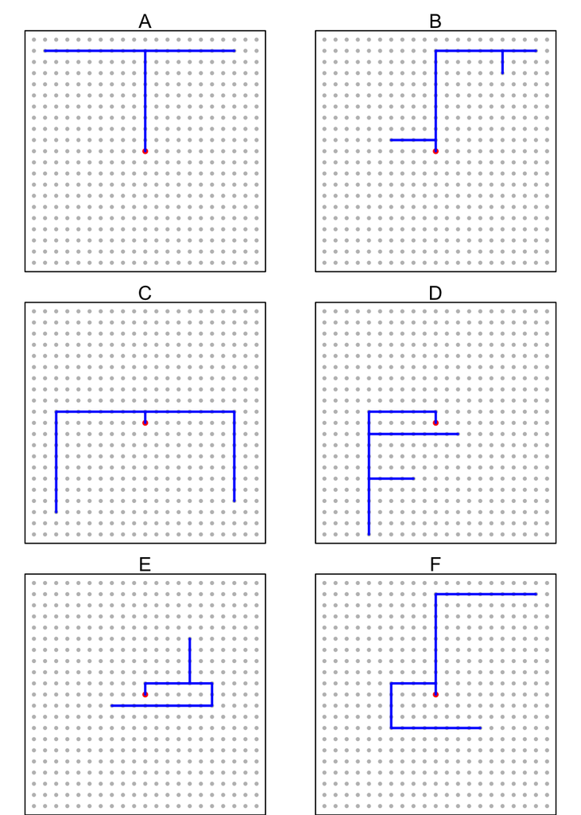

ABCDEF

The correct answer is F.

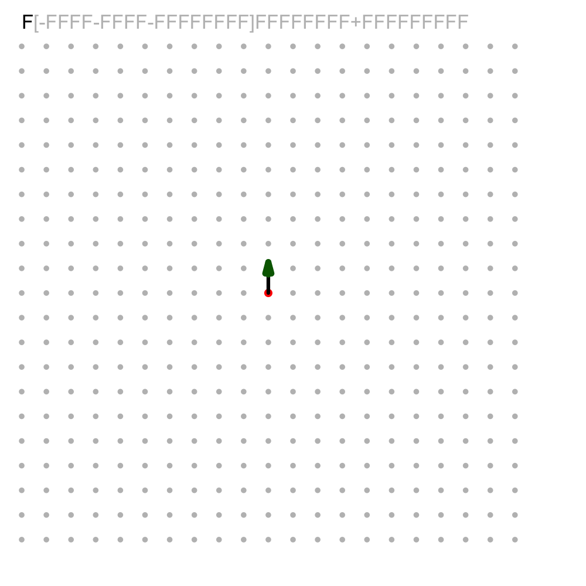

A turtle starts at the central red dot facing North. It uses the following commands:

- Character `F` means drag pen **Forward**
- Character `+` means turn 90° right (clockwise)
- Character `-` means turn 90° left (counterclockwise)
- Character `X` means hop forward without drawing
- Character `[` means save current position at top of pile
- Character `]` means teleport to saved position (use position at top of pile and remove that position from pile)

Use the following command string:

`F[-FFFFFFFF+FFFFFFFF]FFFFFFFF[-FFFFFFFF]+FFFFFFFFF`

Which drawing is correct?

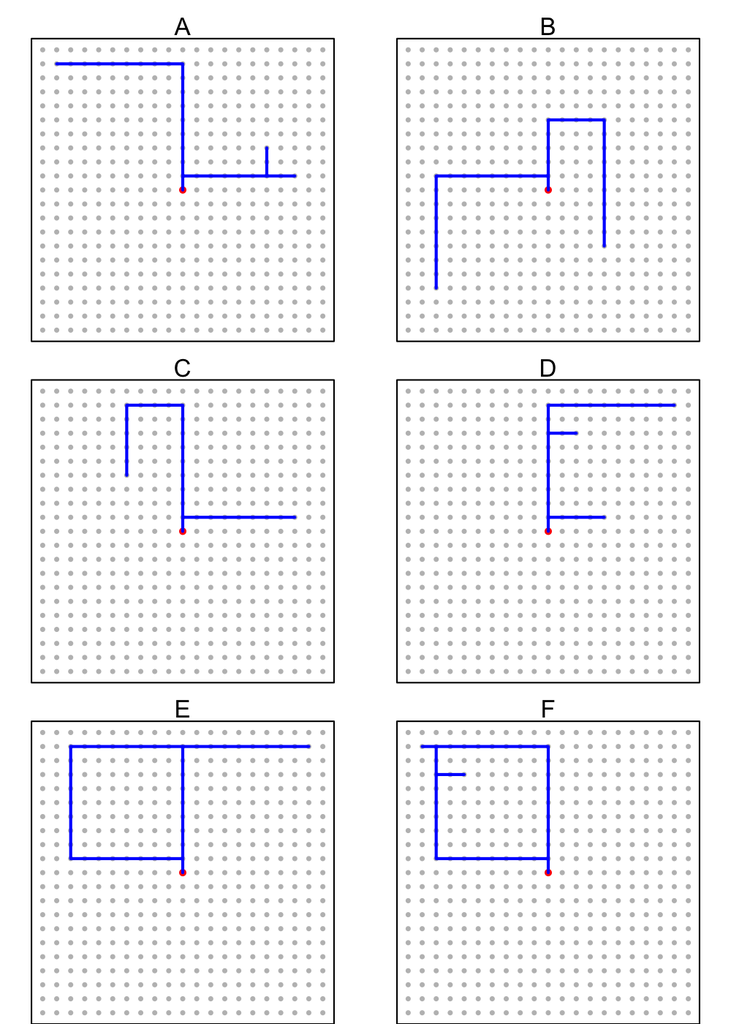

ABCDEF

The correct answer is E.

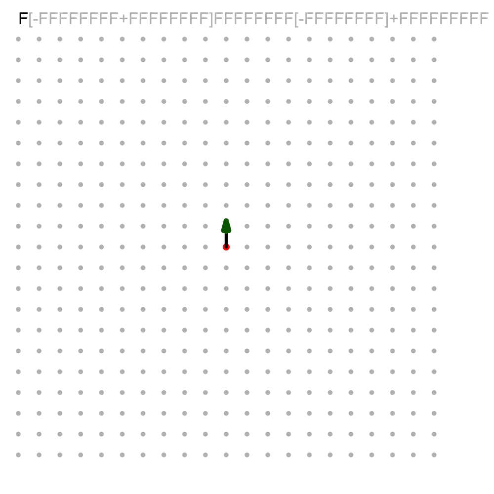